# Consumer Loan Payoff Prediction with Machine Learning

Maria Palmer  
09.04.2019

### Background

The success of any financial organization that owns and subsequently collects on consumer loans depends on how precicely the risk of default can be evaluated at the moment when the loan is granted.

The risk can depend on the following factors:

- Demographic characteristics in the customer profile (age, gender, education, income, employment, marital status, race and ethnicity)
- Payment plan characteristics (principal value and face value, interest rate, number of payments, frequency of payments, day of the payment)
- Customer credit history (past behavior is a predictor of the future behavior)
- State of economy (growing unemployment rates can increase the risk of default)

### Data

The data for this analysis come from kaggle.com datasets. It contains 500 observations and properties of the loan and properties of the customer. We exclude variables which cannot be used for prediction since they are not known at the time when loan is granted (e.g. past_due_days or paid_off_time)

```
'data.frame':   500 obs. of  11 variables:
 $ Loan_ID       : Factor w/ 500 levels "xqd12160159",..: 472 474 5 6 7 470 8 9 471 10 ...
 $ loan_status   : Factor w/ 2 levels "COLLECTION","PAIDOFF": 2 2 2 2 2 2 2 2 2 2 ...
 $ Principal     : int  1000 1000 1000 1000 1000 300 1000 1000 1000 800 ...
 $ terms         : int  30 30 30 15 30 7 30 30 30 15 ...
 $ effective_date: Factor w/ 7 levels "9/10/2016","9/11/2016",..: 6 6 6 6 7 7 7 7 7 1 ...
 $ due_date      : Factor w/ 25 levels "10/10/2016","10/11/2016",..: 7 7 7 19 8 14 8 8 8 21 ...
 $ paid_off_time : Factor w/ 321 levels "","10/1/2016 10:18",..: 171 101 254 211 223 321 99 87 108 234 ...
 $ past_due_days : int  NA NA NA NA NA NA NA NA NA NA ...
 $ age           : int  45 50 33 27 28 35 29 36 28 26 ...
 $ education     : Factor w/ 4 levels "Bechalor","college",..: 3 1 1 2 2 4 2 2 2 2 ...
 $ Gender        : Factor w/ 2 levels "female","male": 2 1 1 2 1 2 2 2 2 2 ...
```

### The application

The application is a proof of concept and its goal is to provide an easy tool to compare various machine learning algorithms and select various features to predict the outcome. In this case we want to predict if customer is likely to default on his loan. User has a possibility to choose the ML method and include/exclude features contributing to the model. In the output part user can evaluate the model based on Accuracy for both training and test datasets and confusion matrices. Another positive effect of such a tool is interpritability. By adding possibility to turn on/off features we let user try various combinations and estimate the importance of each feature for the prediction f the outcome.

This is where the application is hosted:

https://lisiaka.shinyapps.io/shinydebt/

### The server.R file of the presentation

The server.R file takes input from ui.R, trains the model and shows two confusion matrices for training data and test data.

```r
themethod<-'rf' #input$themethod - selected method
selected<-1:6 #c(1,as.integer(input$predictors))- features
ts<-training[,selected]
model<-train(data=ts,loan_status~.,method=themethod)
mod_training<-predict(model)
confusion_matrix <- as.data.frame(table(mod_training, training$loan_status))
accuracy<-sum(mod_training==training$loan_status)/length(mod_training)
plot1<-ggplot(data = confusion_matrix,mapping = aes(x = mod_training,    y = Var2)) +  geom_tile(aes(fill = Freq)) + geom_text(aes(label = sprintf("%1.0f", Freq)), vjust = 1) + scale_fill_gradient(low = "blue", high = "red", trans = "log")
plot1+labs(x='prediction',y='actual data',title=paste("Training data. Accuracy: ",round(accuracy,2)))
```

### Results

High prediction accuracy wasn't achieved with any method and/or combination of features. Many significant variables are missing from this dataset: demography and loan terms are not sufficient to make a prediction of default. It is likely with a larger dataset (more observations) higher accuracy can be attained.

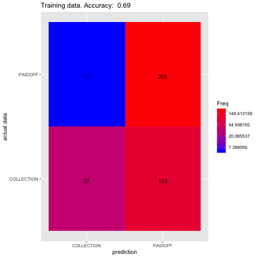

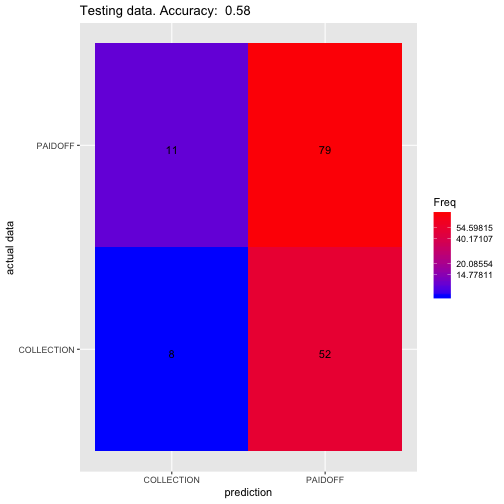